# finalxproject.rmd

Natalie Palmer

12/13/2021

1. A brief description of the research question and experiment (with citation to the paper, and link to find the data)

   St-Amour, S., Cailhol, L., Ruocco, A. C., & Bernard, P.(2021, April 1). Acute Effect of Physical Exercise on Negative Affect in Borderline Personality Disorder: A Pilot Study.

   ```
                      https://doi.org/10.31236/osf.io/mdcuh
                              https://osf.io/t2egx/
   ```

- The aim of this study was to guage how exercise impacts negative affect in individuals with borderline personality disorder. Negative affect was induced in all participants and levels of arousal (FAS) and levels of feeling (FS) were measured before and after the negative induction strategy.

  This report reproduces the repeated measures t test used to evaluate the effectiveness of the negative mood induction strategy performed in the experiment by Amour, Cailhol, Ruocco, and Bernard (2021).

```r
library(data.table)
library(papaja)
library(dplyr)
```

```r
library(ggplot2)

library(readr)
arousal_feeling_scores <- read_csv("finalxproject/arousal_feeling_scores.csv")
# feeling valence scores
feeling_before <- arousal_feeling_scores$feeling_before
feeling_after <- arousal_feeling_scores$feeling_after

sd(feeling_before)
```

```
## [1] 2.52678
```

```r
sd(feeling_after)
```

```
## [1] 2.580885
```

```r
mean(feeling_before)
```

```
## [1] 1.333333
```

```r
mean(feeling_after)
```

```
## [1] -0.2592593
```

```r
(feeling_before_after <- t.test(arousal_feeling_scores$feeling_before,
                        arousal_feeling_scores$feeling_after,
                        paired = TRUE))
```

```
##
##  Paired t-test
##
## data:  arousal_feeling_scores$feeling_before and arousal_feeling_scores$feeling_after
## t = 2.4102, df = 26, p-value = 0.02332
## alternative hypothesis: true difference in means is not equal to 0
## 95 percent confidence interval:
##  0.2343307 2.9508544
## sample estimates:
## mean of the differences
##                1.592593
```

```r
# arousal scores

arousal_before <- arousal_feeling_scores$arousal_before
arousal_after <- arousal_feeling_scores$arousal_after

sd(arousal_before)
```

```
## [1] 2.525652
```

```r
sd(arousal_after)
```

```
## [1] 2.527343
```

```r
mean(arousal_before)
```

```
## [1] 5.074074
```

```r
mean(arousal_after)
```

```
## [1] 6.814815
```

```r
#apa_print(arousal_before_after)$full_result

(arousal_before_after <- t.test(arousal_feeling_scores$arousal_before,
                        arousal_feeling_scores$arousal_after,
                        paired = TRUE))
```

```
##
##  Paired t-test
##
## data:  arousal_feeling_scores$arousal_before and arousal_feeling_scores$arousal_after
## t = -3.2845, df = 26, p-value = 0.00292
## alternative hypothesis: true difference in means is not equal to 0
## 95 percent confidence interval:
##  -2.8301531 -0.6513284
## sample estimates:
## mean of the differences
##               -1.740741
```

The re-analysis for the feeling scores showed, $M_d = 1.59$, 95% CI $[0.23$, $2.95]$, $t(26) = 2.41$, $p = .023$.

```r
library(dplyr)
library(ggplot2)

knitr::kable(colMeans(arousal_feeling_scores))
```

|  | x |
| --- | --- |
| arousal_before | 5.0740741 |
| arousal_after | 6.8148148 |
| feeling_before | 1.3333333 |
| feeling_after | -0.2592593 |

```r
table_means <- knitr::kable(colMeans(arousal_feeling_scores))
```

3. Graph of means

[figure not shown]

```r
# feeling means

library(dplyr)

feeling_mean_scores <- c("1.29", "-0.36")

sections <- c("before", "after")
feeling_mean_scores <- c("1.29", "-0.36")

my_data <- data.frame(sections,feeling_mean_scores)

library(ggplot2)

ggplot(my_data, aes(x = sections, y = feeling_mean_scores))+
  geom_bar(stat="identity")
```

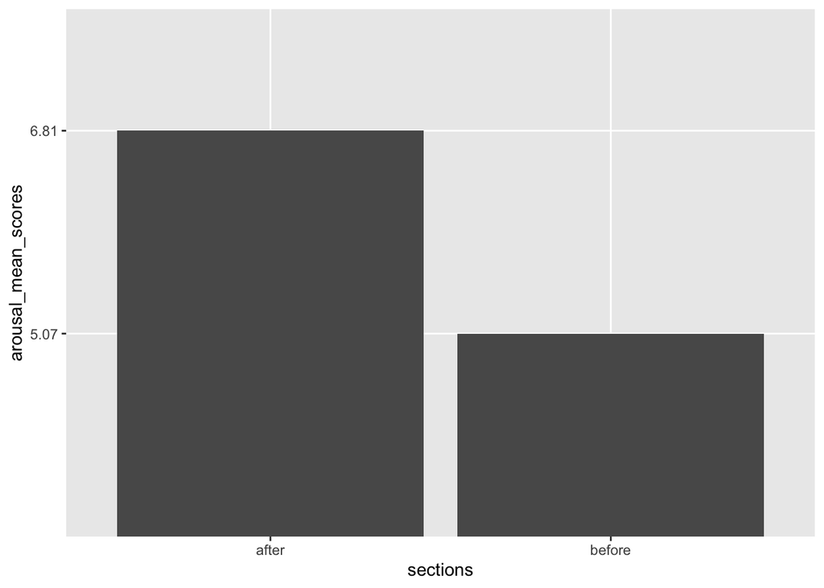

```r
# arousal means

sections <- c("before", "after")
arousal_mean_scores <- c("5.07", "6.81")

my_data <- data.frame(sections,arousal_mean_scores)

library(ggplot2)

ggplot(my_data, aes(x = sections, y = arousal_mean_scores))+
  geom_bar(stat="identity")
```

4. Power Analysis the following reports a power curve analysis for one of the t tests in the design.

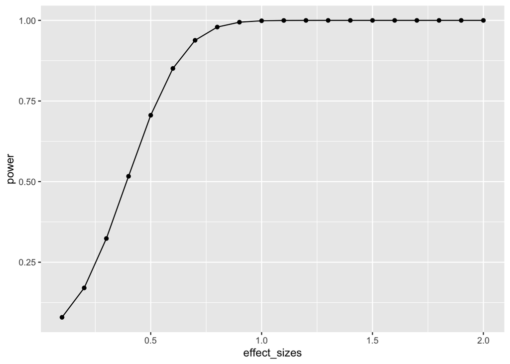

A Power curve for a paired samples t-test with 27 participants

```r
library(pwr)
effect_sizes <- seq(.1,2,.1)
prop_significant <- c()

power <- sapply(effect_sizes,
                FUN = function(x) {
                  pwr.t.test(n=27,
                             d=x,
                             sig.level = .05,
                             type = "paired",
                             alternative = "two.sided")$power})
plot_df <- data.frame(effect_sizes,power)
ggplot(plot_df, aes(x=effect_sizes,
                    y=power))+

  geom_point()+
  geom_line()
```